# CS559: Homework #2

Assignment #2: Due on 3/12/2021 by 11:59 PM

- Change the file name as YourName_S21_CS559_HW2
- Submit the assignment in `ipynb` and `html` formats.
  - You can export the notebook in HTML.
  - Do not compress your files. Please submit files individually.
- All work must be your own and must not be shared with other classmates.
  - Collaboration with classmates or getting help by any people is not acceptable.
  - For impletementation problems, do not copy algorithms from internet.

## Problem 1 - Clustering Using KMeans [35 pts]

The tasks in this problem are:

- impletemenation of KMeans
- confirmation of pre-determined K value

Here, we have a given data set `HW2_Q1_0.csv` containing coordinates of x and y.

1-a. Load the data and add feature name as X and Y for the first and second columns, respectively. (2 pts)

```python
import pandas as pd
import matplotlib.pyplot as plt
import numpy as np
DF = pd.read_csv('HW2_Q1_0.csv', names=['X', 'Y'])
```

1-b. Using `KMeans` from `sklearn.cluster`, determine the appropriate $K$ value for `HW2_Q1_0.csv` and report it. Explain why your pre-determined $K$ value is appropriate. The function `plot_inertia` is provided to you. (4 pts)

```python
from sklearn.cluster import KMeans
kmeans = KMeans()

def plot_inertia(km, X, n_cluster_range):
    inertias = []
    for i in n_cluster_range:
        km.set_params(n_clusters=i)
        km.fit(X)
        inertias.append(km.inertia_)
    plt.plot(n_cluster_range, inertias, marker='o')
    plt.title('Elbow method')
    plt.xlabel('Number of clusters')
    plt.ylabel('Inertia')
    plt.show()

    tabular_result = pd.DataFrame(inertias,
                                  index = ["n = {}".format(i) for i in range(1, len(inertias)+1)],
                                  columns=['Inertia'])

    return tabular_result
```

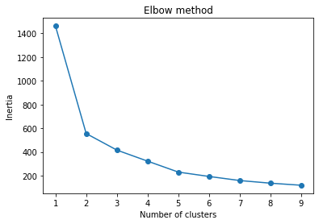

|  | Inertia |
| --- | --- |
| n = 1 | 1462.008530 |
| n = 2 | 555.425223 |
| n = 3 | 415.888690 |
| n = 4 | 322.744582 |
| n = 5 | 230.504896 |
| n = 6 | 193.745547 |
| n = 7 | 159.305209 |
| n = 8 | 137.027017 |
| n = 9 | 119.571885 |

```python
plot_inertia(kmeans,DF,range(1, 10))
```

Based on the eblow plot method, it seems that 2 clusters would be an optimal number of clusters. This is because the slope of the elbow plot levels off after 2 clusters.

1-c. Make a scatter plot of y vs. x. Do you think your pre-determined $K$ value is acceptable. Explain why. If you do not think your pre-determined $K$ value is not correct, explain what a new pre-determined $K$ value must be. (4 pts)

```
<function matplotlib.pyplot.show(close=None, block=None)>
```

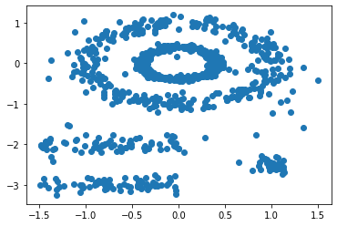

```python
plt.scatter(DF.X, DF.Y)
plt.show
```

Based on the graph above, I no longer believe that K=2 is the appropriate K value. From the graph above, there appears to be at least 3 different clusters (The top circle, the bottom left lines, and the bottom right cluster), with up to arguably 5 distinct clusters above (the top outer circle, top inner circle, top bottom left line, bottom bottom left line, and bottom right cluster).

I will be making my new pre-determined value 5, since there are 5 distinct groups of clusters.

1-d. Impletement `MY_KMean` that does the KMeans clustering. When you do the implementation, you may use linear algebra built-in functions from `Numpy`. Do not use `KMeans` directly. (10 pts)

```python
import numpy as np
from scipy.spatial.distance import cdist
from sklearn.datasets import load_digits
from sklearn.decomposition import PCA
import random

# 1.Randomly assign  an integer label, from 1 to K (where K is the number of clusters), to each of the observations.
#      These serve as initial cluster assignments for the observations.

# 2.Iterate until the cluster assignments stop changing:
#   1) For each of the K clusters, compute the cluster’s new centroid.
#   2) Assign each observation to the cluster whose centroid is closest (closest is measured using Euclidean distance).

def MY_KMean(x, k, no_of_iterations):
    centroids = []
    thelist = np.zeros(x.shape[0])

    for i in range(x.shape[0]):
        thelist[i] = random.randint(1, k)
    # Randomly assigns everything in the list a label

    # calculates the initial centroids
    for i in range(1,k+1):
        xaccum = 0
        yaccum = 0
        count = 0

        for j in range(x.shape[0]):
            if(thelist[i] == j):
                xaccum += x.iloc[i][0]
                yaccum += x.iloc[i][1]
                count += 1

        centroids.append([xaccum / count, yaccum / count])
    #print(centroids)
    counter = 0

    while(counter < no_of_iterations):
        # Find the distance between each observation from each cluster
        # find out the cluster that is closest to the observation
        # assign the observation to that cluster

        # after that recalculate the centroids
        distances = []
        for i in range(0, x.shape[0]):
            distancearray = []
            for j in range(0, k):
                distance = np.linalg.norm(x.iloc[i].values - centroids[j])
                distancearray.append(distance)
                # fill it in one row at a time

            distances.append(distancearray)

        for i in range(0, thelist.shape[0]):
            array = distances[i]
            thelist[i] = array.index(min(array))

        for a in range(0,k):
            xaccum1 = 0
            yaccum1 = 0
            count1 = 0

            for b in range(x.shape[0]):
                if(thelist[a] == b):
                    xaccum1 += x.iloc[a][0]
                    yaccum1 += x.iloc[a][1]
                    count1 += 1

            centroids[a] = [xaccum1 / count, yaccum1 / count1]
        counter += 1

    labels = thelist
    return [centroids, labels]
```

1-e. Using `MY_KMeans` with the pre-determined $K$ value from 1-c, do the clustering. After the clustering, find the centroid of each cluster id and report. (4 pts)

```python
(centroids, labels) = MY_KMean(DF, 5, 200)
print(centroids)
print(labels)
```

[output not shown]

1-f. Add the cluter label to the dataframe and call it `Class`. Make a plot and indicate the centroids. (2 pts)

```
            X         Y  Class
0   -0.452720 -0.018213    0.0
1   -0.169793  1.073745    1.0
2    1.128729 -2.395042    2.0
3    0.122506 -0.973069    3.0
4   -0.409200  0.129649    4.0
..        ...       ...    ...
820  0.944727  0.365376    1.0
821 -0.161625 -0.358271    0.0
822  0.147787  0.905077    1.0
823 -0.159311  0.425800    4.0
824 -0.090622  0.394709    4.0

[825 rows x 3 columns]
```

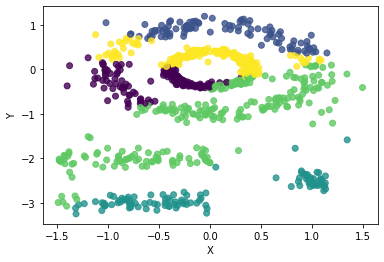

```python
newDF = DF.copy()
newDF['Class'] = labels
print(newDF)


plt.scatter(DF.iloc[:,0],DF.iloc[:,1], c=labels, alpha=0.8)
plt.xlabel('X')
plt.ylabel('Y')
plt.show()
```

1-g. Load a given data set `HW2_Q1_1.csv`. Here you have true cluter ids. (4 pts)

- Make a box plot by the ids and make a discrete statistical analysis. Here, you also have to make a box plot with your result from 1-f and compare.
- Is your pre-determined $K$ value the same as the true $K$ value? Explain.
- If not, do the clustering again using `MY_KMeans` with the true $K$ value.

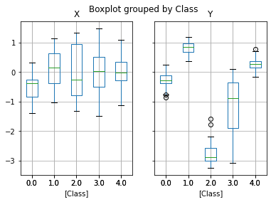

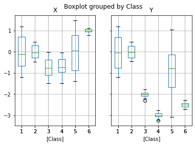

```python
DF_True = pd.read_csv('HW2_Q1_1.csv', names=['X', 'Y', 'Class'])

boxplot = newDF.boxplot(by='Class')
boxplot2 = DF_True.boxplot(by='Class')
```

It looks like my K value is not the true K value. The K value I used was 5, while the true K value seems to be 6. Also, my code is labeling on the range 0-4, while the true is on the range 1-6.

```python
(centroids, labels) = MY_KMean(DF, 6, 200)
```

1-h. Evalaute your result. (5 pts)

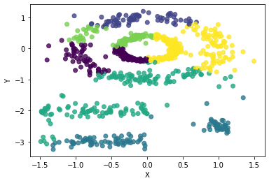

```
            X         Y  Class
0   -0.452720 -0.018213    0.0
1   -0.169793  1.073745    1.0
2    1.128729 -2.395042    2.0
3    0.122506 -0.973069    3.0
4   -0.409200  0.129649    4.0
..        ...       ...    ...
820  0.944727  0.365376    5.0
821 -0.161625 -0.358271    0.0
822  0.147787  0.905077    1.0
823 -0.159311  0.425800    4.0
824 -0.090622  0.394709    4.0

[825 rows x 3 columns]
```

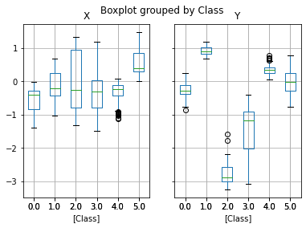

```python
plt.scatter(DF.iloc[:,0],DF.iloc[:,1], c=labels, alpha=0.8)
plt.xlabel('X')
plt.ylabel('Y')
plt.show()

newDF1 = DF.copy()
newDF1['Class'] = labels
print(newDF1)
boxplot = newDF1.boxplot(by='Class')
```

Upon running my code with 6 clusters, my code did separate the the data in to 6 clusters, albeit extremely different from the true clustering.

## Problem 2 - Clustering Using Hierarchal Clustering [10 pts]

In this problem, you will make a dendrogram using Hierarchal clustering method and compare with the result you obtained from Problem #1.

2-a. Do the hierarchal clustering with various distances and linkages. [8 pts]

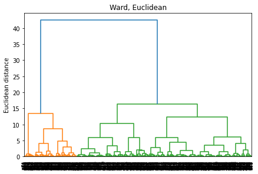

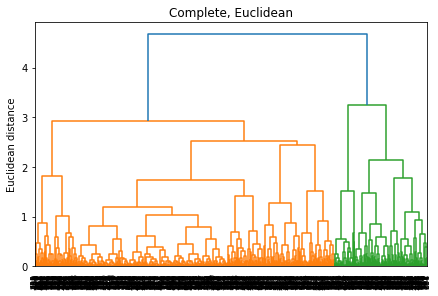

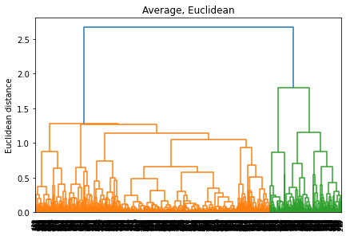

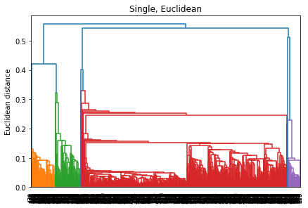

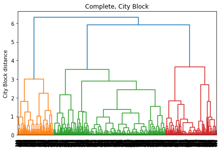

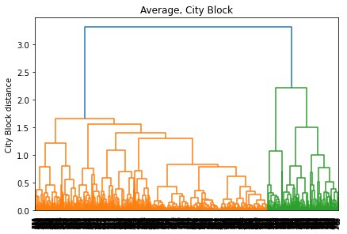

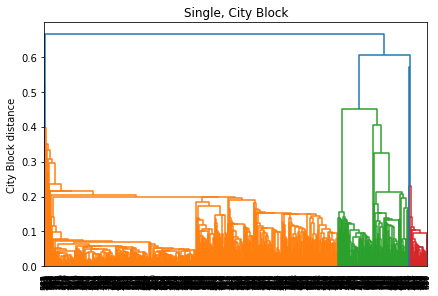

```python
from sklearn.cluster import AgglomerativeClustering
from scipy.cluster.hierarchy import dendrogram, linkage
from scipy.spatial.distance import pdist, squareform
import pandas as pd

hier = AgglomerativeClustering()

hier.set_params(n_clusters = 5)
hier.fit(DF)

def linkage_frame(DF, method, metric):
    row_clusters = linkage(DF, method, metric)
    columns = ['row label 1', 'row label 2', 'distance', 'no. items in clust.']
    index = ['cluster %d' % (i + 1) for i in range(row_clusters.shape[0])]
    linkage_df = pd.DataFrame(row_clusters, columns=columns, index=index)
    return linkage_df

linkage_ward = linkage_frame(DF.values, 'ward', 'euclidean')
linkage_complete = linkage_frame(DF.values, 'complete', 'euclidean')
linkage_average = linkage_frame(DF.values, 'average', 'euclidean')
linkage_single = linkage_frame(DF.values, 'single', 'euclidean')

row_dendr = dendrogram(linkage_ward, leaf_rotation=90, leaf_font_size=8)
plt.tight_layout()
plt.ylabel('Euclidean distance')
plt.title('Ward, Euclidean')
plt.show()

row_dendr1 = dendrogram(linkage_complete, leaf_rotation=90, leaf_font_size=8)
plt.tight_layout()
plt.ylabel('Euclidean distance')
plt.title('Complete, Euclidean')
plt.show()

row_dendr2 = dendrogram(linkage_average, leaf_rotation=90, leaf_font_size=8)
plt.tight_layout()
plt.ylabel('Euclidean distance')
plt.title('Average, Euclidean')
plt.show()

row_dendr3 = dendrogram(linkage_single, leaf_rotation=90, leaf_font_size=8)
plt.tight_layout()
plt.ylabel('Euclidean distance')
plt.title('Single, Euclidean')
plt.show()

linkage_complete_manhattan = linkage_frame(DF.values, 'complete', 'cityblock')
linkage_average_manhattan = linkage_frame(DF.values, 'average', 'cityblock')
linkage_single_manhattan = linkage_frame(DF.values, 'single', 'cityblock')

row_dendr5 = dendrogram(linkage_complete_manhattan, leaf_rotation=90, leaf_font_size=8)
plt.tight_layout()
plt.ylabel('City Block distance')
plt.title('Complete, City Block')
plt.show()

row_dendr6 = dendrogram(linkage_average_manhattan, leaf_rotation=90, leaf_font_size=8)
plt.tight_layout()
plt.ylabel('City Block distance')
plt.title('Average, City Block')
plt.show()

row_dendr7 = dendrogram(linkage_single_manhattan, leaf_rotation=90, leaf_font_size=8)
plt.tight_layout()
plt.ylabel('City Block distance')
plt.title('Single, City Block')
plt.show()
```

2-b. Which distance and linkage provide the best and worst result? You can make numerical and/or graphical comparisons. For example, you can count the number of cluster IDs that are correctly clustered from the true labels and find its ratio. [2 pts]

Especially considering that the true number of clusters is 6, the single euclidean graph gets the closest to that.

Based on looking at the graphs, the distance and linkage that provides the best result is the euclidian distance with single linkage.

The worst result seems to be average city block.

```python
print('-------------Linkage ward euclidian-------------')
linkage_ward_DF = pd.DataFrame(linkage_ward)
print(linkage_ward_DF.head())

print('-------------Linkage complete euclidian-------------')
linkage_euclidian_complete_DF = pd.DataFrame(linkage_complete)
print(linkage_euclidian_complete_DF.head())

print('-------------Linkage average euclidian-------------')
linkage_average_euclidian_DF = pd.DataFrame(linkage_average)
print(linkage_average_euclidian_DF.head())

print('-------------Linkage single euclidian-------------')
linkage_single_euclidian_DF = pd.DataFrame(linkage_single)
print(linkage_single_euclidian_DF.head())


print('-------------Linkage complete manhattan-------------')
linkage_complete_manhattan_DF = pd.DataFrame(linkage_complete_manhattan)
print(linkage_complete_manhattan_DF.head())

print('-------------Linkage average manhattan-------------')
linkage_average_manhattan_DF = pd.DataFrame(linkage_average_manhattan)
print(linkage_average_manhattan_DF.head())

print('-------------Linkage single_manhattan-------------')
linkage_single_manhattan_DF = pd.DataFrame(linkage_single_manhattan)
print(linkage_single_manhattan_DF.head())
```

```
-------------Linkage ward euclidian-------------
           row label 1  row label 2  distance  no. items in clust.
cluster 1        149.0        245.0  0.001565                  2.0
cluster 2        380.0        572.0  0.002063                  2.0
cluster 3        145.0        585.0  0.002680                  2.0
cluster 4          9.0        674.0  0.002777                  2.0
cluster 5        310.0        748.0  0.003792                  2.0
-------------Linkage complete euclidian-------------
           row label 1  row label 2  distance  no. items in clust.
cluster 1        149.0        245.0  0.001565                  2.0
cluster 2        380.0        572.0  0.002063                  2.0
cluster 3        145.0        585.0  0.002680                  2.0
cluster 4          9.0        674.0  0.002777                  2.0
cluster 5        310.0        748.0  0.003792                  2.0
-------------Linkage average euclidian-------------
           row label 1  row label 2  distance  no. items in clust.
cluster 1        149.0        245.0  0.001565                  2.0
cluster 2        380.0        572.0  0.002063                  2.0
cluster 3        145.0        585.0  0.002680                  2.0
cluster 4          9.0        674.0  0.002777                  2.0
cluster 5        310.0        748.0  0.003792                  2.0
-------------Linkage single euclidian-------------
           row label 1  row label 2  distance  no. items in clust.
cluster 1        149.0        245.0  0.001565                  2.0
cluster 2        380.0        572.0  0.002063                  2.0
cluster 3        145.0        585.0  0.002680                  2.0
cluster 4          9.0        674.0  0.002777                  2.0
cluster 5        310.0        748.0  0.003792                  2.0
-------------Linkage complete manhattan-------------
           row label 1  row label 2  distance  no. items in clust.
cluster 1        149.0        245.0  0.002193                  2.0
cluster 2        380.0        572.0  0.002461                  2.0
cluster 3        145.0        585.0  0.003765                  2.0
cluster 4          9.0        674.0  0.003909                  2.0
cluster 5        403.0        418.0  0.004220                  2.0
-------------Linkage average manhattan-------------
           row label 1  row label 2  distance  no. items in clust.
cluster 1        149.0        245.0  0.002193                  2.0
cluster 2        380.0        572.0  0.002461                  2.0
cluster 3        145.0        585.0  0.003765                  2.0
cluster 4          9.0        674.0  0.003909                  2.0
cluster 5        403.0        418.0  0.004220                  2.0
-------------Linkage single_manhattan-------------
           row label 1  row label 2  distance  no. items in clust.
cluster 1        149.0        245.0  0.002193                  2.0
cluster 2        380.0        572.0  0.002461                  2.0
cluster 3        145.0        585.0  0.003765                  2.0
cluster 4          9.0        674.0  0.003909                  2.0
cluster 5        403.0        418.0  0.004220                  2.0
```

## Problem 3 - Principal Component Analysis [15 pts]

3-a. Run the following codes.

```python
import numpy as np

np.random.seed(2342)
mu_vec1 = np.array([0,0,0])
cov_mat1 = np.array([[1,0,0],[0,1,0],[0,0,1]])
class1_sample = np.random.multivariate_normal(mu_vec1, cov_mat1, 30).T
assert class1_sample.shape == (3,30), "The matrix has not the dimensions 3x30"

mu_vec2 = np.array([1,1,1])
cov_mat2 = np.array([[1,0,0],[0,1,0],[0,0,1]])
class2_sample = np.random.multivariate_normal(mu_vec2, cov_mat2, 30).T
assert class2_sample.shape == (3,30), "The matrix has not the dimensions 3x30"
```

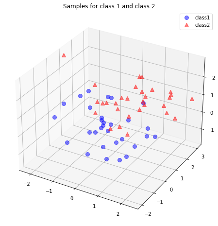

```python
from matplotlib import pyplot as plt
from mpl_toolkits.mplot3d import Axes3D
from mpl_toolkits.mplot3d import proj3d

fig = plt.figure(figsize=(8,8))
ax = fig.add_subplot(111, projection='3d')
plt.rcParams['legend.fontsize'] = 10
ax.plot(class1_sample[0,:], class1_sample[1,:], class1_sample[2,:], 'o', markersize=8, color='blue', alpha=0.5, label='class1')
ax.plot(class2_sample[0,:], class2_sample[1,:], class2_sample[2,:], '^', markersize=8, alpha=0.5, color='red', label='class2')

plt.title('Samples for class 1 and class 2')
ax.legend(loc='upper right')

plt.show()
```

3-b. PCA Implementation. Here, the descriiption of each step and part of codes. You have to fill out the rest process. [10 pts]

```
1. Take the dataset w/o classes.
```

```python
all_samples = np.concatenate((class1_sample, class2_sample), axis=1)
print(all_samples)
assert all_samples.shape == (3,60), "The matrix has not the dimensions 3x60"
```

```
[[-1.25731210e+00  1.85438106e+00  5.05120979e-01  2.08466477e+00
  -7.25580632e-01 -9.41232709e-01  5.53985426e-01  4.34857938e-01
   4.35015806e-01  3.41795404e-01 -5.31445722e-01 -1.71655245e-01
  -1.58464924e+00 -1.96798503e+00  1.29840991e+00 -2.71932303e-01
  -1.00512653e-01  9.43842152e-01 -7.84022623e-02  2.90412574e-01
  -5.17509741e-01 -6.41899387e-01 -3.26402119e-02  9.64963962e-01
   6.47917403e-01  1.64806311e+00  1.10348562e+00 -7.63280064e-01
  -4.42145436e-01 -1.38525900e-01  4.56554125e-02  1.48916082e+00
   1.56784735e+00  1.69162299e+00  9.47102333e-01  2.00807061e+00
   1.14223350e+00  2.67143803e-01 -1.02312085e+00  1.80828452e-01
   8.21558668e-01  1.46343184e-01  9.56751611e-01 -4.97242624e-02
   2.20893140e+00  1.37515883e+00  2.17590429e+00  3.87865502e-01
  -6.34556632e-01 -2.18300291e+00  2.09093283e+00  8.08481441e-01
   7.15656750e-01  5.14013667e-01  1.72150108e+00  1.42269560e+00
   8.80822246e-01  2.37298676e+00  4.12508729e-01  1.00476590e+00]
 [-7.22224452e-01  8.02655864e-01  3.77904458e-01 -3.71117513e-01
   1.21676202e-01  1.60168665e+00  6.96883827e-03 -5.84816031e-01
  -4.60004983e-01 -1.94569883e+00  8.24045471e-01  2.64499905e-01
  -1.07089130e+00  3.25899402e-01  1.38514669e-01  5.05555154e-01
  -9.07142600e-01 -1.96945582e+00 -5.30341666e-01  1.57286511e+00
   1.36142095e+00  1.82340104e+00  2.07154611e-02 -3.11571510e-01
   2.15483504e+00  4.65312289e-01 -1.94848182e-01 -4.55225016e-01
   1.48645363e+00 -8.96379189e-01 -7.80253747e-01  5.93971965e-01
   2.69575556e-01  2.38907252e+00  1.38573373e+00  1.17403014e+00
   8.26152052e-01  1.65752048e+00  1.19173851e+00 -4.12957043e-01
   2.58834801e+00  8.95082120e-01  1.64707018e+00 -3.97298075e-01
   1.31718451e+00 -6.44049372e-01  1.47201561e+00  7.59143514e-01
   1.43607988e+00  7.50365057e-01  1.28364658e+00  4.54719908e-01
   1.64605223e+00 -4.11784431e-01  2.92077187e+00 -1.02023213e-01
   1.54715561e+00  3.03129053e+00  2.46884700e-01 -5.77557490e-01]
 [-8.17466890e-01 -1.91529140e-01 -1.81704821e+00  1.05953806e+00
   1.82002700e+00 -7.69146098e-01 -5.37772573e-01 -1.16467679e+00
   3.66205179e-01 -7.56611262e-02 -2.51153596e-02 -1.73048333e-02
   7.22508969e-01  5.59267448e-01 -5.52098903e-01 -1.06751938e-02
   1.71131797e+00  1.61927280e+00  1.14955206e-01 -3.01945280e-01
   8.80968376e-01 -1.06106761e+00 -1.03830072e+00 -2.04587788e-03
   4.77183269e-01 -5.52093266e-02 -1.01381845e+00  1.84839270e+00
   7.70587244e-01  3.22512741e-01  2.93764466e+00  2.05656787e+00
   1.98396343e+00  1.05785065e+00  2.47615690e+00  1.40473695e+00
   1.07004831e+00 -1.19206162e-01 -1.41143593e-01  1.78047032e+00
   1.08741277e+00  6.95747000e-01  7.93995900e-01  1.76514951e+00
   2.14127938e+00  6.24900823e-01  1.88551676e+00  1.48724441e+00
   4.55219731e-01  2.99196998e+00  9.48782830e-01  1.76045685e+00
   2.28907495e+00  4.98046182e-01 -4.48084147e-01  2.92795116e+00
   1.55322631e+00  8.62041076e-01  1.47714890e+00  8.90369320e-01]]
```

```
2. Compute the d-dimentional mean vector.
```

```python
mean_x = np.mean(all_samples[0])
mean_y = np.mean(all_samples[1])
mean_z = np.mean(all_samples[2])

mean_vector = np.array([[mean_x],[mean_y],[mean_z]])

print('Mean Vector:\n', mean_vector)
```

```
Mean Vector:
 [[0.47343911]
 [0.52653958]
 [0.73360656]]
```

```
3. Compute the scatter matrix as following.
```

$$\textbf{S}=\sum_{k=1}^N (\textbf{x}_k-\bar{\textbf{x}})(\textbf{x}_k-\bar{\textbf{x}})^T$$

where $\bar{\textbf{x}}$ is the mean vector.

```python
scatter_matrix = np.zeros((3,3))
for i in range(all_samples.shape[1]):
    scatter_matrix += (all_samples[:, i] - mean_vector) * ((all_samples[:, i] - mean_vector).T)
print('Scatter Matrix:\n', scatter_matrix)
```

```
Scatter Matrix:
 [[66.33488145 15.78641252  5.3207374 ]
 [15.78641252 73.06156823 -3.30316783]
 [ 5.3207374  -3.30316783 73.75083116]]
```

```
Then compute the covariance matrix using `np.cov()` function.
```

```python
cov_mat = np.cov([all_samples[0, :], all_samples[1, :], all_samples[2, :]])
print('Covariance Matrix:\n', cov_mat)
```

```
Covariance Matrix:
 [[ 1.12432002  0.27043376  0.15901633]
 [ 0.27043376  1.23833166 -0.01238244]
 [ 0.15901633 -0.01238244  1.25001409]]
```

```
4. Compute eigenvectors and corresponding eigenvalues using np.linalg.eig().
```

```python
# eigenvectors and eigenvalues for the from the scatter matrix
eig_val_sc, eig_vec_sc = np.linalg.eig(scatter_matrix)

# eigenvectors and eigenvalues for the from the covariance matrix
eig_val_cov, eig_vec_cov = np.linalg.eig(cov_mat)

for i in range(len(eig_val_sc)):
    eigvec_sc = eig_vec_sc[:,i].reshape(1,3).T
    eigvec_cov = eig_vec_cov[:,i].reshape(1,3).T
    assert eigvec_sc.all() == eigvec_cov.all(), 'Eigenvectors are not identical'

    print('Eigenvector {}: \n{}'.format(i+1, eigvec_sc))
    print('Eigenvalue {} from scatter matrix: {}'.format(i+1, eig_val_sc[i]))
    print('Eigenvalue {} from covariance matrix: {}'.format(i+1, eig_val_cov[i]))
    print('Scaling factor: ', eig_val_sc[i]/eig_val_cov[i])
    print(60 * '-')
```

```
Eigenvector 1:
[[-0.75178136]
 [ 0.60045154]
 [ 0.27254861]]
Eigenvalue 1 from scatter matrix: 51.797230184430404
Eigenvalue 1 from covariance matrix: 0.8592333131868217
Scaling factor:  60.28307956580382
------------------------------------------------------------
Eigenvector 2:
[[0.63809873]
 [0.76667006]
 [0.07104244]]
Eigenvalue 2 from scatter matrix: 85.89450024480108
Eigenvalue 2 from covariance matrix: 1.4956003667822708
Scaling factor:  57.431451711662746
------------------------------------------------------------
Eigenvector 3:
[[ 0.16629731]
 [-0.22732131]
 [ 0.95951562]]
Eigenvalue 3 from scatter matrix: 75.45555041070776
Eigenvalue 3 from covariance matrix: 1.2578320969790298
Scaling factor:  59.988571282233494
------------------------------------------------------------
```

```
5. Check the eigenvector and eigenvalue calculation. This code is provided as well as the visualization of eigenvectors.
```

```python
for i in range(len(eig_val_sc)):
    eigv = eig_vec_sc[:,i].reshape(1,3).T
    np.testing.assert_array_almost_equal(scatter_matrix.dot(eigv), eig_val_sc[i] * eigv,
                                         decimal=6, err_msg='', verbose=True)
```

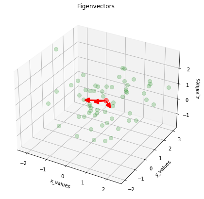

```python
from matplotlib.patches import FancyArrowPatch


class Arrow3D(FancyArrowPatch):
    def __init__(self, xs, ys, zs, *args, **kwargs):
        FancyArrowPatch.__init__(self, (0,0), (0,0), *args, **kwargs)
        self._verts3d = xs, ys, zs

    def draw(self, renderer):
        xs3d, ys3d, zs3d = self._verts3d
        xs, ys, zs = proj3d.proj_transform(xs3d, ys3d, zs3d, renderer.M)
        self.set_positions((xs[0],ys[0]),(xs[1],ys[1]))
        FancyArrowPatch.draw(self, renderer)

fig = plt.figure(figsize=(7,7))
ax = fig.add_subplot(111, projection='3d')

ax.plot(all_samples[0,:], all_samples[1,:], all_samples[2,:], 'o', markersize=8, color='green', alpha=0.2)
ax.plot([mean_x], [mean_y], [mean_z], 'o', markersize=10, color='red', alpha=0.5)
for v in eig_vec_sc.T:
    a = Arrow3D([mean_x, v[0]], [mean_y, v[1]], [mean_z, v[2]], mutation_scale=20, lw=3, arrowstyle="-|>", color="r")
    ax.add_artist(a)
ax.set_xlabel('x_values')
ax.set_ylabel('y_values')
ax.set_zlabel('z_values')

plt.title('Eigenvectors')

plt.show()
```

```
6. Sort the eigenvectors by descreasing eigenvalues.

The idea is that since the eigenvectors will form the axes of new feature subspace, we want to drop for eigenvectors with the lowest eigenvalues that bear the least information about the distribution of the data.
```

```python
# Make a list of (eigenvalue, eigenvector) tuples
eig_pairs = [(np.abs(eig_val_sc[i]), eig_vec_sc[:,i]) for i in range(len(eig_val_sc))]

# Sort the (eigenvalue, eigenvector) tuples from high to low
eig_pairs.sort(reverse=True)

# Visually confirm that the list is correctly sorted by decreasing eigenvalues
for i in eig_pairs:
    print(i[0])
```

```
85.89450024480108
75.45555041070776
51.797230184430404
```

1. Choose *k* eigenvectors with the largest eigenvalues.

   We are going to reduce a 3-D feature space to a 2-D feature subspace. To do so, we combine the two eigenvectors with the highest eigenvalues to construct our $d\times k$-D eigenvector matrix $\bf{W}$.

```python
matrix_w = np.hstack((eig_pairs[0][1].reshape(3,1), eig_pairs[1][1].reshape(3,1)))
print('Matrix W:\n', matrix_w)
```

```
Matrix W:
 [[ 0.63809873  0.16629731]
 [ 0.76667006 -0.22732131]
 [ 0.07104244  0.95951562]]
```

```
8. Transform the samples onto the new subspace.

The new subspace equation is
```

$${\bf y}={\bf W}^T\times {\bf x}$$

```python
transformed = matrix_w.T.dot(all_samples)
assert transformed.shape == (2,60), "The matrix is not 2x60 dimensional."
```

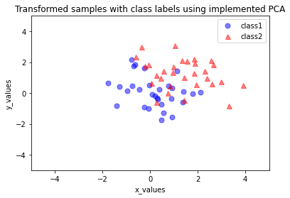

```python
plt.plot(transformed[0,0:30], transformed[1,0:30], 'o', markersize=7, color='blue', alpha=0.5, label='class1')
plt.plot(transformed[0,30:60], transformed[1,30:60], '^', markersize=7, color='red', alpha=0.5, label='class2')
plt.xlim([-5,5])
plt.ylim([-5,5])
plt.xlabel('x_values')
plt.ylabel('y_values')
plt.legend()
plt.title('Transformed samples with class labels using implemented PCA')

plt.show()
```

3-c. Using `PCA` from sklearn, make a visualization comparison with the result in 3-b and evaluation your impletemented PCA. [5 pts]

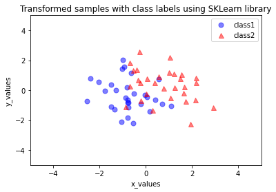

```python
from sklearn.decomposition import PCA

sklearnpca = PCA(n_components = 2)
sklearntransformed = (sklearnpca.fit_transform(all_samples.T)).T

plt.plot(sklearntransformed[0,0:30], sklearntransformed[1,0:30], 'o', markersize=7, color='blue', alpha=0.5, label='class1')
plt.plot(sklearntransformed[0,30:60], sklearntransformed[1,30:60], '^', markersize=7, color='red', alpha=0.5, label='class2')
plt.xlim([-5,5])
plt.ylim([-5,5])
plt.xlabel('x_values')
plt.ylabel('y_values')
plt.legend()
plt.title('Transformed samples with class labels using SKLearn library')

plt.show()
```

The above is a visualization after running the same plotting algorithm used in section 3-b onto transformed data using the sklearn PCA library.

From looking at the two graphs, we can see that the the transformed samples with class labels using the SKLearn library is slightly more skewed leftwards than the transformed samples with class labels using what we implemented above.